# MicroN filtering summary

### 2.4 Abundance filtering

Since every phyla are associated with Fungi and there's nothing to exclude, we move on to the abundance filter where we'll be excluding low abundant OTUs (threshold= 0.01%)

```r
phy_ITS_f1
```

```
## phyloseq-class experiment-level object
## otu_table()   OTU Table:         [ 1072 taxa and 23 samples ]
## sample_data() Sample Data:       [ 23 samples by 5 sample variables ]
## tax_table()   Taxonomy Table:    [ 1072 taxa by 6 taxonomic ranks ]
```

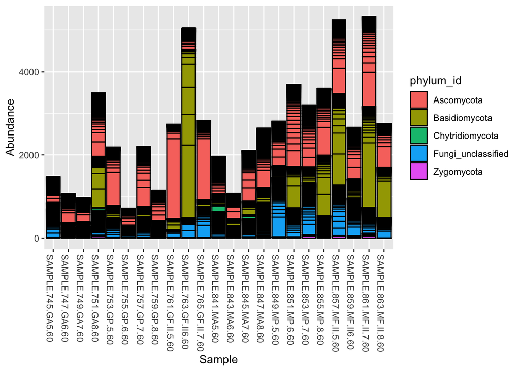

### 2.5 Last checks

Let's finally check the range of reads per sample on the filtered ITS phyloseq object:

```r
min(sample_sums(phy_ITS_f1))
```

```
## [1] 717
```

```r
mean(sample_sums(phy_ITS_f1))
```

```
## [1] 2646.304
```

```r
max(sample_sums(phy_ITS_f1))
```

```
## [1] 5321
```

## 3. Filtering 16S

### 3.1 Initial 16S phyloseq

Taking a look at the initial phyloseq object

```r
phy_16S
```

```
## phyloseq-class experiment-level object
## otu_table()   OTU Table:         [ 7550 taxa and 24 samples ]
## sample_data() Sample Data:       [ 24 samples by 5 sample variables ]
## tax_table()   Taxonomy Table:    [ 7550 taxa by 6 taxonomic ranks ]
```

Plotting the phyloseq object colored by phylum

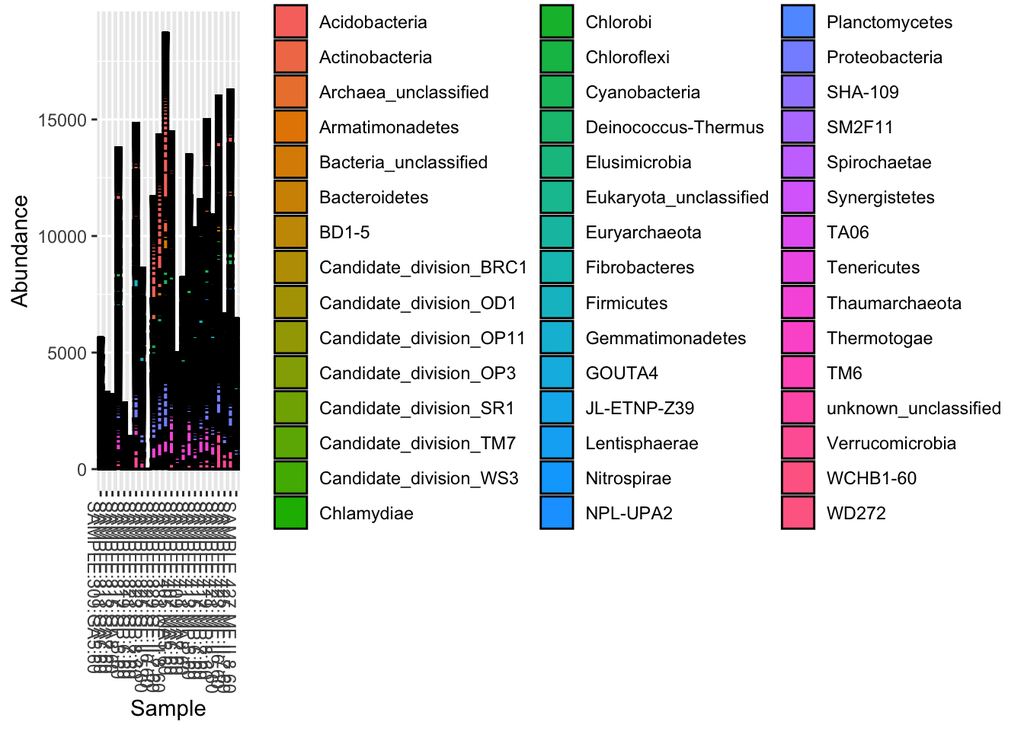

```r
plot_bar(phy_16S, fill='phylum_id') #there's a sample that failed and must be removed
```

### 3.2 Removing failed sample

Removing this sample and checking the phyloseq object again:

```r
phy_16S_pruned
```

```
## phyloseq-class experiment-level object
## otu_table()   OTU Table:         [ 7550 taxa and 23 samples ]
## sample_data() Sample Data:       [ 23 samples by 5 sample variables ]
## tax_table()   Taxonomy Table:    [ 7550 taxa by 6 taxonomic ranks ]
```

### 3.3 Taxonomic filtering

Check if there are unspecific taxonomic groups

```r
get_taxa_unique(phy_16S_pruned, taxonomic.rank = 'domain_id')
```

```
## [1] "Bacteria"  "Archaea"   "unknown"   "Eukaryota"
```

We will want to remove all the OTUs associated with Eukaryota and maybe also the Unclassified, but let's first take a look at how many OTUs represent these taxa, as well as their abundance across the samples

```
## [1] 39
```

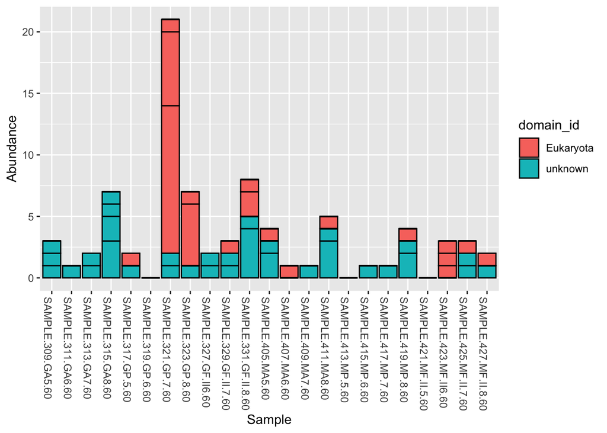

Based on this, we will be removing both Eukaryotes and OTUs unclassified at the domain level. Let's take a look at the new trimmed phyloseq object:

```r
phy_16S_f1
```

```
## phyloseq-class experiment-level object
## otu_table()   OTU Table:         [ 7511 taxa and 23 samples ]
## sample_data() Sample Data:       [ 23 samples by 5 sample variables ]
## tax_table()   Taxonomy Table:    [ 7511 taxa by 6 taxonomic ranks ]
```

### 3.4 Abundance filtering

Let's then apply the low abundance filter (remove OTUs with an overall abundance less than 0.01%) and take a look at the filtered object:

```r
phy_16S_f2
```

```
## phyloseq-class experiment-level object
## otu_table()   OTU Table:         [ 1486 taxa and 23 samples ]
## sample_data() Sample Data:       [ 23 samples by 5 sample variables ]
## tax_table()   Taxonomy Table:    [ 1486 taxa by 6 taxonomic ranks ]
```

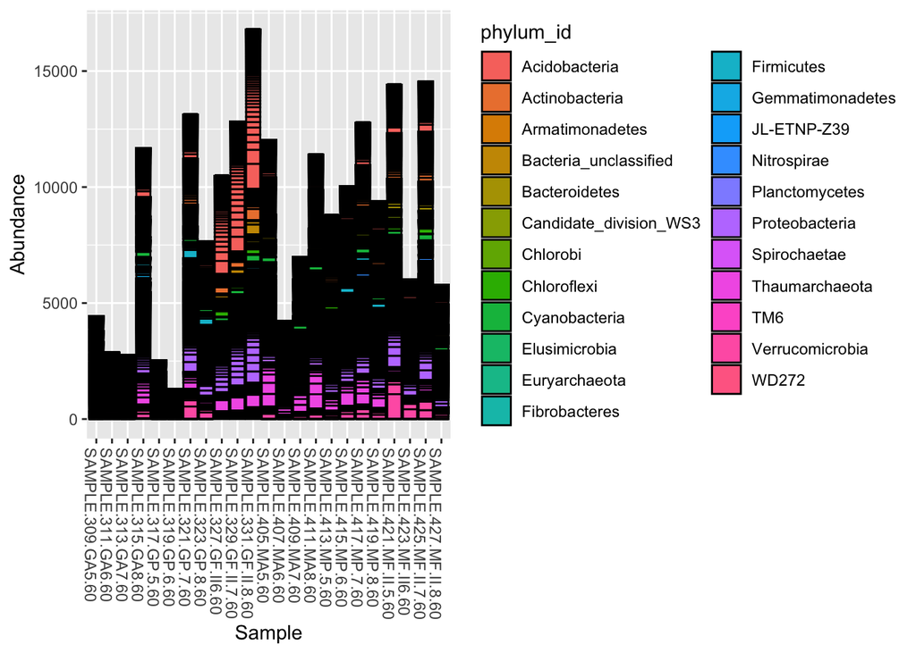

### 3.5 Last checks

Let's finally check the range of reads per sample on the filtered 16S phyloseq object:

```r
min(sample_sums(phy_16S_f2))
```

```
## [1] 1302
```

```r
mean(sample_sums(phy_16S_f2))
```

```
## [1] 8823.522
```

```r
max(sample_sums(phy_16S_f2))
```

```
## [1] 16795
```